# Polynomial Regression Modeling

2023-09-29

## Polynomial Regression

In this report we will contruct polynomial regression models and assess training and testing error related to these models. For the data we have three distinct, color-coded datasets are available, each generated from a polynomial function with a scalar input x and added noise. We plan to find the right value for K, from options of 1 to 10. The right value would optimize flexibily to the mdoel correctly fits the data.

We will now visualize these datasets to analyze any elementary differences and patterns. Note for each dataset we have a small traing set, large training set and test set. In the plot we have diffrentiated the data with the shape of the point and colour.

## Generate and visualize data from 3 datasets

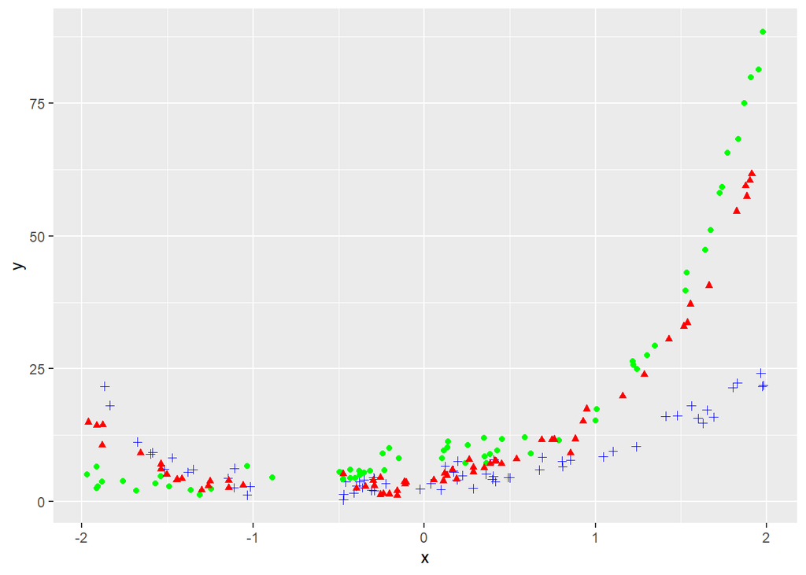

```r
ggplot(data = NULL, aes(x = x, y = y)) +
  geom_point(data = trains1, color= "blue", shape = 3) +
  geom_point(data = trainl1, color= "blue", shape = 3) +
  geom_point(data = tst1, color= "blue", shape = 3) +
  geom_point(data = trains2, color= "green") +
  geom_point(data = trainl2, color= "green") +
  geom_point(data = tst2, color= "green") +
  geom_point(data = trains3, color= "red", shape = 17) +
  geom_point(data = trainl3, color= "red", shape = 17) +
  geom_point(data = tst3, color= "red", shape = 17)
```

We can see the data has noticeable differences in their trends. We will now create one polynomial regression model based on the first dataset. Here we will have K = 15 and 5.

## Step 2: Practice Polreg

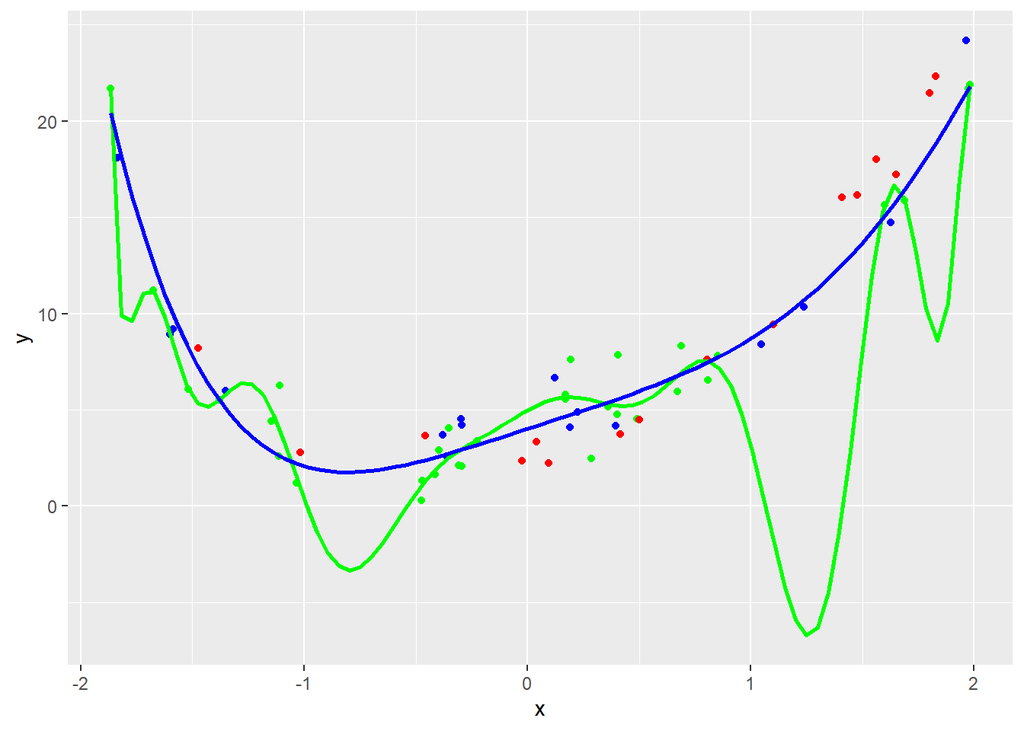

```r
# Visualize data
ggplot(data = NULL, aes(x = x, y = y)) +
  geom_point(data = trains1, color= "blue") +
  geom_point(data = trainl1, color= "green") +
  geom_point(data = tst1, color= "red") +
  stat_smooth(data = trainl1, method = "lm", formula = y ~ poly(x, 15, raw = TRUE), se=FALSE, color = "green") +
  stat_smooth(data = trainl1, method = "lm", formula = y ~ poly(x, 5, raw = TRUE), se=FALSE, color = "blue")
```

The warmup is over. We now will display 3 models for each dataset. These models have been choosen because they have interesting shapes and Errors, which we will analyze further. We will also display the Training and Testing errors for all 10 models for each dataset, and graph the Error against K to assess overfitting.

## Compare model fits for K = 1, 2, 9 for dataset1

```r
library(cowplot)
plot1 <- ggplot(data = NULL, aes(x = x, y = y)) +
  geom_point(data = trains1, color= "blue") +
  geom_point(data = trainl1, color= "green") +
  geom_point(data = tst1, color= "red") +
  stat_smooth(data = trainl1, method = "lm", formula = y ~ poly(x, 1, raw = TRUE), se=FALSE, color = "green") +
  stat_smooth(data = trains1, method = "lm", formula = y ~ poly(x, 1, raw = TRUE), se=FALSE, color = "blue")
  ggtitle(paste("d=",1))
```

```
## $title
## [1] "d= 1"
##
## attr(,"class")
## [1] "labels"
```

```r
plot2 <- ggplot(data = NULL, aes(x = x, y = y)) +
  geom_point(data = trains1, color= "blue") +
  geom_point(data = trainl1, color= "green") +
  geom_point(data = tst1, aes(y = tst1$y, color= "TestData")) +
  stat_smooth(data = trainl1, method = "lm", formula = y ~ poly(x, 2, raw = TRUE), se=FALSE, aes(y = y, color = "LargeDataSet")) +
  stat_smooth(data = trains1, method = "lm", formula = y ~ poly(x, 2, raw = TRUE), se=FALSE, aes(y = y, color = "SmallDataSet")) +
  scale_colour_manual("", breaks = c("LargeDataSet", "SmallDataSet", "TestData"), values = c("green", "blue", "red")) +
  theme(legend.position = "bottom")
  ggtitle(paste("d=",2))
```

```
## $title
## [1] "d= 2"
##
## attr(,"class")
## [1] "labels"
```

```r
plot3 <- ggplot(data = NULL, aes(x = x, y = y)) +
  geom_point(data = trains1, color= "blue") +
  geom_point(data = trainl1, color= "green") +
  geom_point(data = tst1, color= "red") +
  stat_smooth(data = trainl1, method = "lm", formula = y ~ poly(x, 9, raw = TRUE), se=FALSE, color = "green") +
  stat_smooth(data = trains1, method = "lm", formula = y ~ poly(x, 9, raw = TRUE), se=FALSE, color = "blue")
  ggtitle(paste("d=",9))
```

```
## $title
## [1] "d= 9"
##
## attr(,"class")
## [1] "labels"
```

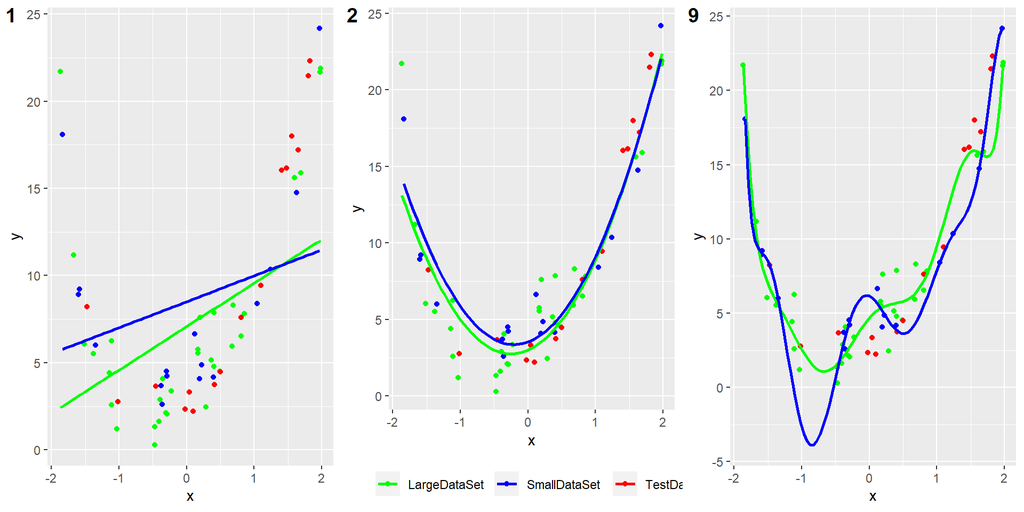

```r
plot_grid(plot1, plot2, plot3, labels = c("1", "2", "9"), ncol=3)
```

## Compare MSE for different values of K from 1:10 for dataset1 for small

```r
mse_train <- c()
mse_test <- c()
for (d in 1:10){
  model <- lm(y ~ poly(x, d, raw = TRUE), data = trains1)
  train_fit <- model %>% predict(trains1)
  train_mse <- mean((trains1$y-train_fit)^2)
  mse_train[d] <- train_mse
  test_fit <- model %>% predict(tst1)
  test_mse <- mean((tst1$y-test_fit)^2)
  mse_test <- append(mse_test, test_mse)
}
mse_train
```

```
##  [1] 30.5970560  3.4179382  3.4178707  0.7531743  0.6324904  0.5597749
##  [7]  0.5594512  0.3269135  0.2154683  0.2139205
```

```r
mse_test
```

```
##  [1] 36.263921  2.697836  2.694161  5.730823  4.480259  5.225270  5.212052
##  [8]  7.615309  8.433024 10.015600
```

```r
mse <- data.frame(
  x = 1:length(mse_train),
  y1 = mse_train,
  y2 = mse_test
)
mse
```

```
##     x         y1        y2
## 1   1 30.5970560 36.263921
## 2   2  3.4179382  2.697836
## 3   3  3.4178707  2.694161
## 4   4  0.7531743  5.730823
## 5   5  0.6324904  4.480259
## 6   6  0.5597749  5.225270
## 7   7  0.5594512  5.212052
## 8   8  0.3269135  7.615309
## 9   9  0.2154683  8.433024
## 10 10  0.2139205 10.015600
```

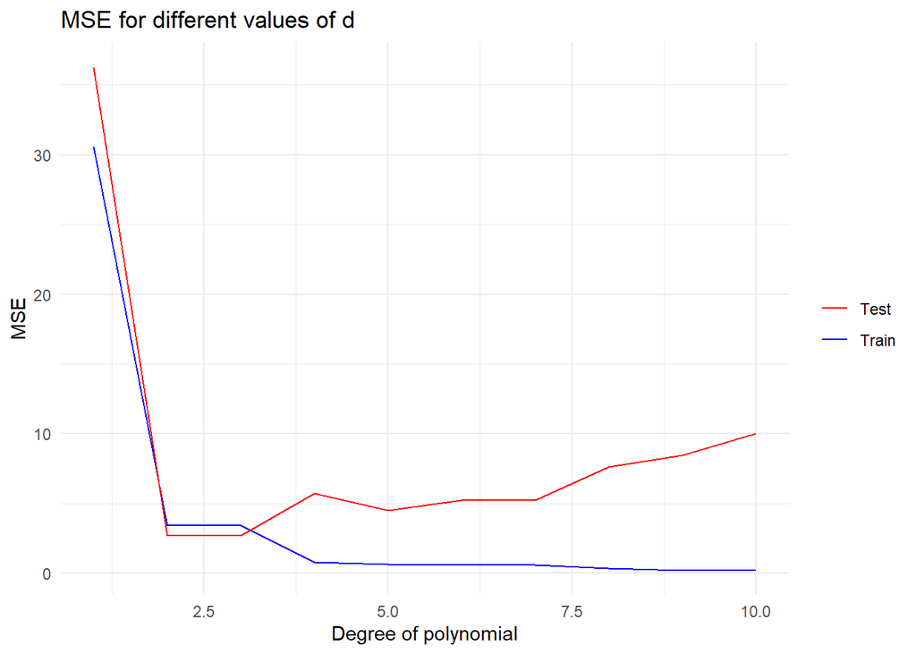

```r
ggplot(mse, aes(x = x)) +
  geom_line(aes(y = y1, color = "Train"), linetype = "solid") +
  geom_line(aes(y = y2, color = "Test"), linetype = "solid") +
  labs(
    title = "MSE for different values of d",
    x = "Degree of polynomial",
    y = "MSE"
  ) +
  scale_color_manual(values = c("Train" = "blue", "Test" = "red")) +
  theme_minimal() +
  theme(legend.title = element_blank())
```

## Compare MSE for different values of K from 1:10 for dataset1 for large

```r
mse_train <- c()
mse_test <- c()
for (d in 1:10){
  model <- lm(y ~ poly(x, d, raw = TRUE), data = trainl1)
  train_fit <- model %>% predict(trainl1)
  train_mse <- mean((trainl1$y-train_fit)^2)
  mse_train[d] <- train_mse
  test_fit <- model %>% predict(tst1)
  test_mse <- mean((tst1$y-test_fit)^2)
  mse_test <- append(mse_test, test_mse)
}
mse_train
```

```
##  [1] 28.771670  5.663779  3.870969  2.105473  1.996179  1.950310  1.662847
##  [8]  1.465249  1.460575  1.391780
```

```r
mse_test
```

```
##  [1] 30.407972  2.099441  2.647116  6.244540  4.505849  4.809946  5.674647
##  [8]  6.152269  6.927680  5.169355
```

```r
mse <- data.frame(
  x = 1:length(mse_train),
  y1 = mse_train,
  y2 = mse_test
)
mse
```

```
##     x        y1        y2
## 1   1 28.771670 30.407972
## 2   2  5.663779  2.099441
## 3   3  3.870969  2.647116
## 4   4  2.105473  6.244540
## 5   5  1.996179  4.505849
## 6   6  1.950310  4.809946
## 7   7  1.662847  5.674647
## 8   8  1.465249  6.152269
## 9   9  1.460575  6.927680
## 10 10  1.391780  5.169355
```

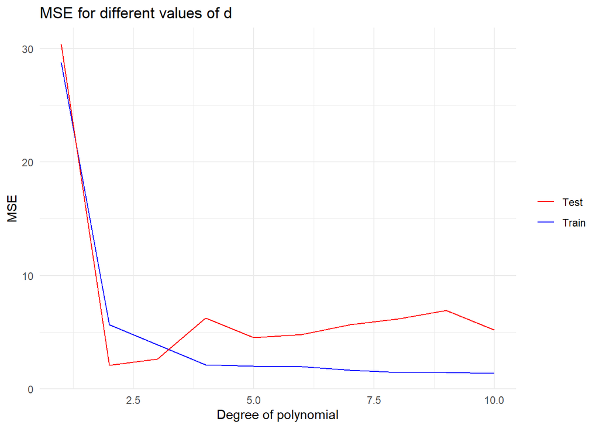

```r
ggplot(mse, aes(x = x)) +
  geom_line(aes(y = y1, color = "Train"), linetype = "solid") +
  geom_line(aes(y = y2, color = "Test"), linetype = "solid") +
  labs(
    title = "MSE for different values of d",
    x = "Degree of polynomial",
    y = "MSE"
  ) +
  scale_color_manual(values = c("Train" = "blue", "Test" = "red")) +
  theme_minimal() +
  theme(legend.title = element_blank())
```

## Compare model fits for K = 1, 5, 10 for dataset2

```r
library(cowplot)
plot1 <- ggplot(data = NULL, aes(x = x, y = y)) +
  geom_point(data = trains2, color= "blue") +
  geom_point(data = trainl2, color= "green") +
  geom_point(data = tst2, color= "red") +
  stat_smooth(data = trainl2, method = "lm", formula = y ~ poly(x, 1, raw = TRUE), se=FALSE, color = "green") +
  stat_smooth(data = trains2, method = "lm", formula = y ~ poly(x, 1, raw = TRUE), se=FALSE, color = "blue")
  ggtitle(paste("d=",1))
```

```
## $title
## [1] "d= 1"
##
## attr(,"class")
## [1] "labels"
```

```r
plot2 <- ggplot(data = NULL, aes(x = x, y = y)) +
  geom_point(data = trains2, color= "blue") +
  geom_point(data = trainl2, color= "green") +
  geom_point(data = tst2, aes(y = tst1$y, color= "TestData")) +
  stat_smooth(data = trainl2, method = "lm", formula = y ~ poly(x, 5, raw = TRUE), se=FALSE, aes(y = y, color = "LargeDataSet")) +
  stat_smooth(data = trains2, method = "lm", formula = y ~ poly(x, 5, raw = TRUE), se=FALSE, aes(y = y, color = "SmallDataSet")) +
  scale_colour_manual("", breaks = c("LargeDataSet", "SmallDataSet", "TestData"), values = c("green", "blue", "red")) +
  theme(legend.position = "bottom")
  ggtitle(paste("d=",2))
```

```
## $title
## [1] "d= 2"
##
## attr(,"class")
## [1] "labels"
```

```r
plot3 <- ggplot(data = NULL, aes(x = x, y = y)) +
  geom_point(data = trains2, color= "blue") +
  geom_point(data = trainl2, color= "green") +
  geom_point(data = tst2, color= "red") +
  stat_smooth(data = trainl2, method = "lm", formula = y ~ poly(x, 10, raw = TRUE), se=FALSE, color = "green") +
  stat_smooth(data = trains2, method = "lm", formula = y ~ poly(x, 10, raw = TRUE), se=FALSE, color = "blue")
  ggtitle(paste("d=",9))
```

```
## $title
## [1] "d= 9"
##
## attr(,"class")
## [1] "labels"
```

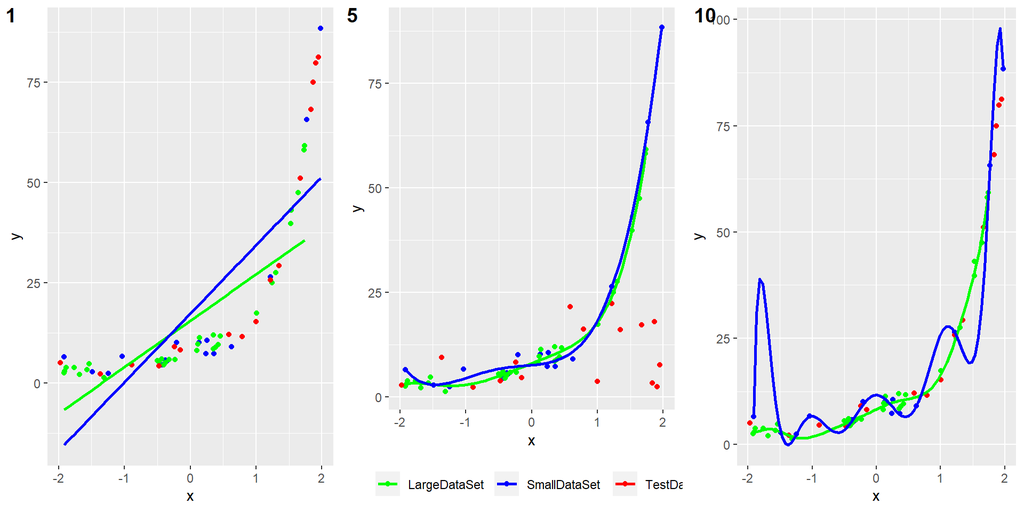

```r
plot_grid(plot1, plot2, plot3, labels = c("1", "5", "10"), ncol=3)
```

## Compare MSE for different values of K from 1:10 for dataset2 for small

```r
mse_train <- c()
mse_test <- c()
for (d in 1:10){
  model <- lm(y ~ poly(x, d, raw = TRUE), data = trains2)
  train_fit <- model %>% predict(trains2)
  train_mse <- mean((trains2$y-train_fit)^2)
  mse_train[d] <- train_mse
  test_fit <- model %>% predict(tst2)
  test_mse <- mean((tst2$y-test_fit)^2)
  mse_test <- append(mse_test, test_mse)
}
mse_train
```

```
##  [1] 230.4644715  41.3685662  10.7218579   2.6314825   2.5868560   2.5028073
##  [7]   2.4282592   1.6970748   1.5913625   0.4771826
```

```r
mse_test
```

```
##  [1] 298.282128  82.644932  22.988975   5.629353   6.167853   6.199751
##  [7]   6.724829  12.357727   9.757942 286.988990
```

```r
mse <- data.frame(
  x = 1:length(mse_train),
  y1 = mse_train,
  y2 = mse_test
)
mse
```

```
##     x          y1         y2
## 1   1 230.4644715 298.282128
## 2   2  41.3685662  82.644932
## 3   3  10.7218579  22.988975
## 4   4   2.6314825   5.629353
## 5   5   2.5868560   6.167853
## 6   6   2.5028073   6.199751
## 7   7   2.4282592   6.724829
## 8   8   1.6970748  12.357727
## 9   9   1.5913625   9.757942
## 10 10   0.4771826 286.988990
```

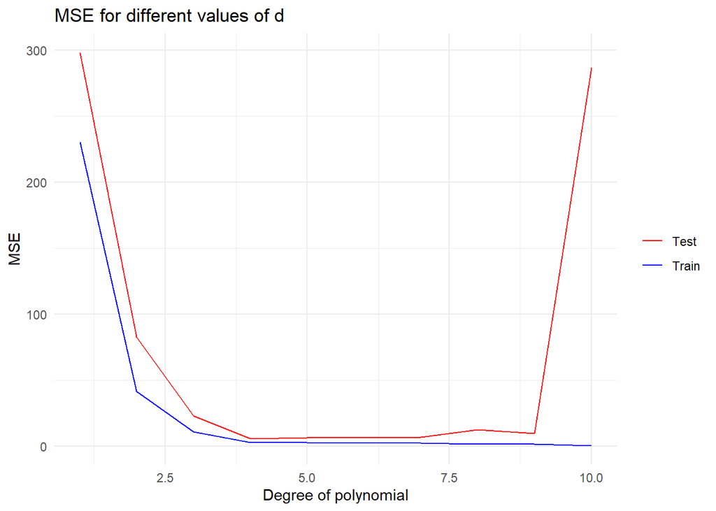

```r
ggplot(mse, aes(x = x)) +
  geom_line(aes(y = y1, color = "Train"), linetype = "solid") +
  geom_line(aes(y = y2, color = "Test"), linetype = "solid") +
  labs(
    title = "MSE for different values of d",
    x = "Degree of polynomial",
    y = "MSE"
  ) +
  scale_color_manual(values = c("Train" = "blue", "Test" = "red")) +
  theme_minimal() +
  theme(legend.title = element_blank())
```

## Compare MSE for different values of K from 1:10 for dataset2 for large

```r
mse_train <- c()
mse_test <- c()
for (d in 1:10){
  model <- lm(y ~ poly(x, d, raw = TRUE), data = trainl2)
  train_fit <- model %>% predict(trainl2)
  train_mse <- mean((trainl2$y-train_fit)^2)
  mse_train[d] <- train_mse
  test_fit <- model %>% predict(tst2)
  test_mse <- mean((tst2$y-test_fit)^2)
  mse_test <- append(mse_test, test_mse)
}
mse_train
```

```
##  [1] 90.240615 17.247976  5.918782  2.201400  1.236614  1.167807  1.166559
##  [8]  1.148219  1.124904  1.070541
```

```r
mse_test
```

```
##  [1] 438.073448 138.863807  41.748537   5.068707   4.612748   2.909381
##  [7]   3.046644   5.727831  25.798191 145.476213
```

```r
mse <- data.frame(
  x = 1:length(mse_train),
  y1 = mse_train,
  y2 = mse_test
)
mse
```

```
##     x        y1         y2
## 1   1 90.240615 438.073448
## 2   2 17.247976 138.863807
## 3   3  5.918782  41.748537
## 4   4  2.201400   5.068707
## 5   5  1.236614   4.612748
## 6   6  1.167807   2.909381
## 7   7  1.166559   3.046644
## 8   8  1.148219   5.727831
## 9   9  1.124904  25.798191
## 10 10  1.070541 145.476213
```

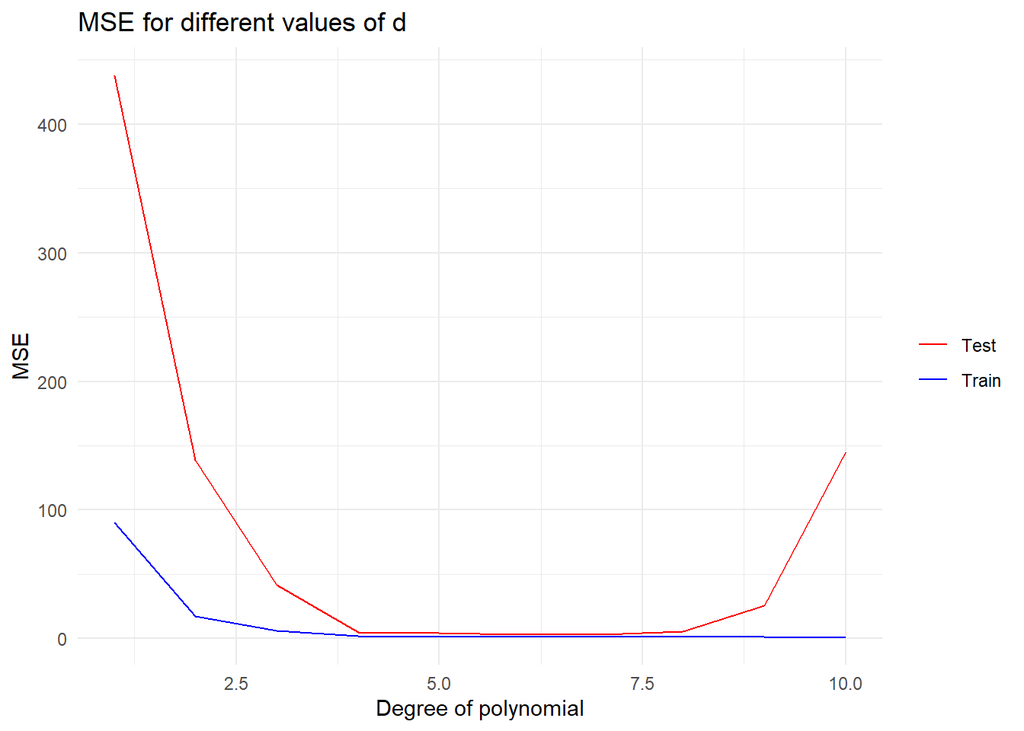

```r
ggplot(mse, aes(x = x)) +
  geom_line(aes(y = y1, color = "Train"), linetype = "solid") +
  geom_line(aes(y = y2, color = "Test"), linetype = "solid") +
  labs(
    title = "MSE for different values of d",
    x = "Degree of polynomial",
    y = "MSE"
  ) +
  scale_color_manual(values = c("Train" = "blue", "Test" = "red")) +
  theme_minimal() +
  theme(legend.title = element_blank())
```

## Compare model fits for K = 1, 4, 10 for dataset3

```r
library(cowplot)
plot1 <- ggplot(data = NULL, aes(x = x, y = y)) +
  geom_point(data = trains3, color= "blue") +
  geom_point(data = trainl3, color= "green") +
  geom_point(data = tst3, color= "red") +
  stat_smooth(data = trainl3, method = "lm", formula = y ~ poly(x, 1, raw = TRUE), se=FALSE, color = "green") +
  stat_smooth(data = trains3, method = "lm", formula = y ~ poly(x, 1, raw = TRUE), se=FALSE, color = "blue")
  ggtitle(paste("d=",1))
```

```
## $title
## [1] "d= 1"
##
## attr(,"class")
## [1] "labels"
```

```r
plot2 <- ggplot(data = NULL, aes(x = x, y = y)) +
  geom_point(data = trains3, color= "blue") +
  geom_point(data = trainl3, color= "green") +
  geom_point(data = tst3, aes(y = tst1$y, color= "TestData")) +
  stat_smooth(data = trainl3, method = "lm", formula = y ~ poly(x, 4, raw = TRUE), se=FALSE, aes(y = y, color = "LargeDataSet")) +
  stat_smooth(data = trains3, method = "lm", formula = y ~ poly(x, 4, raw = TRUE), se=FALSE, aes(y = y, color = "SmallDataSet")) +
  scale_colour_manual("", breaks = c("LargeDataSet", "SmallDataSet", "TestData"), values = c("green", "blue", "red")) +
  theme(legend.position = "bottom")
  ggtitle(paste("d=",2))
```

```
## $title
## [1] "d= 2"
##
## attr(,"class")
## [1] "labels"
```

```r
plot3 <- ggplot(data = NULL, aes(x = x, y = y)) +
  geom_point(data = trains3, color= "blue") +
  geom_point(data = trainl3, color= "green") +
  geom_point(data = tst3, color= "red") +
  stat_smooth(data = trainl3, method = "lm", formula = y ~ poly(x, 10, raw = TRUE), se=FALSE, color = "green") +
  stat_smooth(data = trains3, method = "lm", formula = y ~ poly(x, 10, raw = TRUE), se=FALSE, color = "blue")
  ggtitle(paste("d=",9))
```

```
## $title
## [1] "d= 9"
##
## attr(,"class")
## [1] "labels"
```

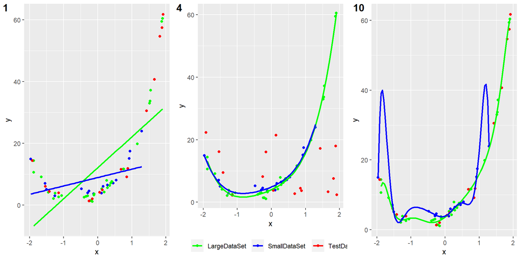

```r
plot_grid(plot1, plot2, plot3, labels = c("1", "4", "10"), ncol=3)
```

## Compare MSE for different values of K from 1:10 for dataset3 for small

```r
mse_train <- c()
mse_test <- c()
for (d in 1:10){
  model <- lm(y ~ poly(x, d, raw = TRUE), data = trains3)
  train_fit <- model %>% predict(trains3)
  train_mse <- mean((trains3$y-train_fit)^2)
  mse_train[d] <- train_mse
  test_fit <- model %>% predict(tst3)
  test_mse <- mean((tst3$y-test_fit)^2)
  mse_test <- append(mse_test, test_mse)
}
mse_train
```

```
##  [1] 27.9602668  2.0936513  2.0934275  1.0210156  0.6336061  0.4772320
##  [7]  0.4295054  0.2164994  0.2135501  0.1342139
```

```r
mse_test
```

```
##  [1] 4.457267e+02 8.300482e+01 8.188052e+01 2.813454e+00 1.700557e+02
##  [6] 9.593601e+02 1.808998e+01 1.405410e+05 3.418487e+05 1.237510e+07
```

```r
mse <- data.frame(
  x = 1:length(mse_train),
  y1 = mse_train,
  y2 = mse_test
)
mse
```

```
##     x         y1           y2
## 1   1 27.9602668 4.457267e+02
## 2   2  2.0936513 8.300482e+01
## 3   3  2.0934275 8.188052e+01
## 4   4  1.0210156 2.813454e+00
## 5   5  0.6336061 1.700557e+02
## 6   6  0.4772320 9.593601e+02
## 7   7  0.4295054 1.808998e+01
## 8   8  0.2164994 1.405410e+05
## 9   9  0.2135501 3.418487e+05
## 10 10  0.1342139 1.237510e+07
```

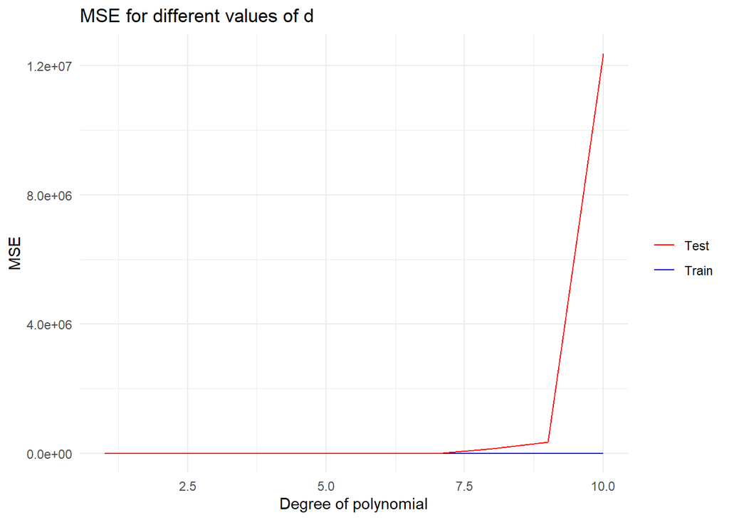

```r
ggplot(mse, aes(x = x)) +
  geom_line(aes(y = y1, color = "Train"), linetype = "solid") +
  geom_line(aes(y = y2, color = "Test"), linetype = "solid") +
  labs(
    title = "MSE for different values of d",
    x = "Degree of polynomial",
    y = "MSE"
  ) +
  scale_color_manual(values = c("Train" = "blue", "Test" = "red")) +
  theme_minimal() +
  theme(legend.title = element_blank())
```

## Compare MSE for different values of d from 1:10 for dataset3 for large

```r
mse_train <- c()
mse_test <- c()
for (d in 1:10){
  model <- lm(y ~ poly(x, d, raw = TRUE), data = trainl3)
  train_fit <- model %>% predict(trainl3)
  train_mse <- mean((trainl3$y-train_fit)^2)
  mse_train[d] <- train_mse
  test_fit <- model %>% predict(tst3)
  test_mse <- mean((tst3$y-test_fit)^2)
  mse_test <- append(mse_test, test_mse)
}
mse_train
```

```
##  [1] 126.4981013   8.7626039   4.9185201   1.2860424   1.0110309   0.9917137
##  [7]   0.9904877   0.8572736   0.8078638   0.7686187
```

```r
mse_test
```

```
##  [1] 220.938068  16.324654   7.392462   1.970684   2.086371   2.158517
##  [7]   2.099530   2.871639   2.446062   3.697097
```

```r
mse <- data.frame(
  x = 1:length(mse_train),
  y1 = mse_train,
  y2 = mse_test
)
mse
```

```
##     x          y1         y2
## 1   1 126.4981013 220.938068
## 2   2   8.7626039  16.324654
## 3   3   4.9185201   7.392462
## 4   4   1.2860424   1.970684
## 5   5   1.0110309   2.086371
## 6   6   0.9917137   2.158517
## 7   7   0.9904877   2.099530
## 8   8   0.8572736   2.871639
## 9   9   0.8078638   2.446062
## 10 10   0.7686187   3.697097
```

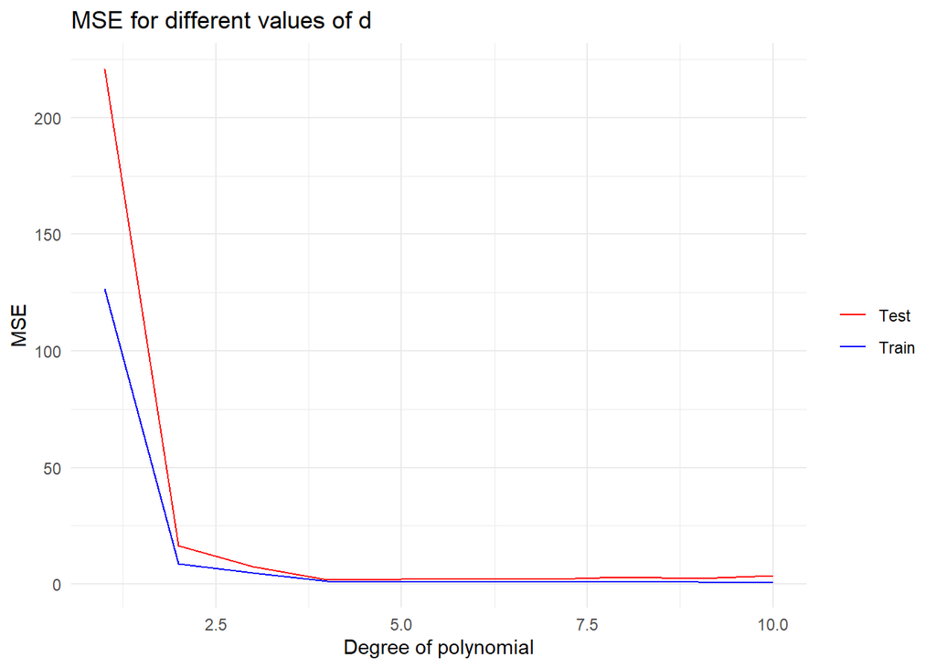

```r
ggplot(mse, aes(x = x)) +
  geom_line(aes(y = y1, color = "Train"), linetype = "solid") +
  geom_line(aes(y = y2, color = "Test"), linetype = "solid") +
  labs(
    title = "MSE for different values of d",
    x = "Degree of polynomial",
    y = "MSE"
  ) +
  scale_color_manual(values = c("Train" = "blue", "Test" = "red")) +
  theme_minimal() +
  theme(legend.title = element_blank())
```

## Analysis

For the first dataset, **K = 2** optimizes the flexibility.

For the third dataset, **K = 4** optimizes the flexibility.

For the smaller data one noticable difference is a greater amount of variability in the smaller dataset, which causes much more variance in the models and higher error.

**K = 1** always underfit the data and **K = 10** always overfit the data.

## Appendix

```r
library(tidyverse)
library(ggplot2)
library(readxl)

trains1 = read.csv("Data\\Dataset_1 - small_train_1.csv")
trainl1 = read.csv("Data\\Dataset_1 - large_train_1.csv")
tst1 = read.csv("Data\\Dataset_1 - test_data_1.csv")

trains2 = read.csv("Data\\Dataset_1 - small_train_2.csv")
trainl2 = read.csv("Data\\Dataset_1 - large_train_2.csv")
tst2 = read.csv("Data\\Dataset_1 - test_data_2.csv")

trains3 = read.csv("Data\\Dataset_1 - small_train_3.csv")
trainl3 = read.csv("Data\\Dataset_1 - large_train_3.csv")
tst3 = read.csv("Data\\Dataset_1 - test_data_3.csv")
```